# Size Sound Symbolism

Anonymous

2/13/2020

## Preparation:

Load libraries:

```r
library(tidyverse)
library(ranger) # for random forests
library(tuneRanger) # for tuning random forest parameters
library(effsize) # for Cohen's d
library(lsr) # for Cramer's V effect size
```

For citations:

```r
packageVersion('tidyverse')
```

```
## [1] '1.3.0'
```

```r
packageVersion('ranger')
```

```
## [1] '0.12.1'
```

```r
packageVersion('tuneRanger')
```

```
## [1] '0.5'
```

```r
packageVersion('effsize')
```

```
## [1] '0.8.1'
```

```r
packageVersion('lsr')
```

```
## [1] '0.5'
```

Load data:

```r
# Thesaurus.com size adjective data:

adj <- read_csv('../data/thesaurus_dot_com_may23_2020.csv')

# SUBTLEX data for corpus-based POS tags and frequencies:

SUBTL <- read_csv('../data/SUBTLEX_US_with_POS.csv') %>%
  dplyr::select(Word, FREQcount, Dom_PoS_SUBTLEX) %>%
  rename(POS = Dom_PoS_SUBTLEX)

# ELP data for morpheme number:

ELP <- read_csv('../data/ELP_with_POS_cleaned.csv')

# Glasgow norms:

glasgow <- read_csv('../data/glasgow_norms.csv')

# CMU dictionary, and phoneme label metadata:

CMU <- read_csv('../data/CMU_phoneme_counts.csv')
phones <- read_csv('../data/CMU_phonemes.csv')
```

## CMU phoneme labels:

Load in phoneme classifications. They contain formant data from Hillenbrand, Getty, Clark, & Wheeler (1995), “Acoustic characteristics of American English vowels”, JASA — which we are not going to use here. This produced some interesting results in earlier versions of this script, but we decided that mapping existing formant data from just one dialect to phonemic representations (without actual acoustic data) is too problematic.

Get IPA characters for plotting consonants:

```r
phones$IPA <- character(nrow(phones))
phones[phones$Phoneme == 'AA', ]$IPA <- 'ɑ'
phones[phones$Phoneme == 'AE', ]$IPA <- 'æ'
phones[phones$Phoneme == 'AH', ]$IPA <- 'ʌ'
phones[phones$Phoneme == 'AO', ]$IPA <- 'ɔ'
phones[phones$Phoneme == 'AW', ]$IPA <- 'aʊ'
phones[phones$Phoneme == 'AY', ]$IPA <- 'aɪ'
phones[phones$Phoneme == 'B', ]$IPA <- 'b'
phones[phones$Phoneme == 'CH', ]$IPA <- 'tʃ'
phones[phones$Phoneme == 'D', ]$IPA <- 'd'
phones[phones$Phoneme == 'DH', ]$IPA <- 'ð'
phones[phones$Phoneme == 'EH', ]$IPA <- 'ɛ'
phones[phones$Phoneme == 'ER', ]$IPA <- 'ɝ'
phones[phones$Phoneme == 'EY', ]$IPA <- 'eɪ'
phones[phones$Phoneme == 'F', ]$IPA <- 'f'
phones[phones$Phoneme == 'G', ]$IPA <- 'g'
phones[phones$Phoneme == 'HH', ]$IPA <- 'h'
phones[phones$Phoneme == 'IH', ]$IPA <- 'i'
phones[phones$Phoneme == 'IY', ]$IPA <- 'ɪ'
phones[phones$Phoneme == 'JH', ]$IPA <- 'dʒ'
phones[phones$Phoneme == 'K', ]$IPA <- 'k'
phones[phones$Phoneme == 'L', ]$IPA <- 'l'
phones[phones$Phoneme == 'M', ]$IPA <- 'm'
phones[phones$Phoneme == 'N', ]$IPA <- 'n'
phones[phones$Phoneme == 'NG', ]$IPA <- 'ŋ'
phones[phones$Phoneme == 'OW', ]$IPA <- 'oʊ'
phones[phones$Phoneme == 'OY', ]$IPA <- 'ɔɪ'
phones[phones$Phoneme == 'P', ]$IPA <- 'p'
phones[phones$Phoneme == 'R', ]$IPA <- 'r'
phones[phones$Phoneme == 'SH', ]$IPA <- 'ʃ'
phones[phones$Phoneme == 'S', ]$IPA <- 's'
phones[phones$Phoneme == 'T', ]$IPA <- 't'
phones[phones$Phoneme == 'TH', ]$IPA <- 'θ'
phones[phones$Phoneme == 'UH', ]$IPA <- 'ʊ'
phones[phones$Phoneme == 'UW', ]$IPA <- 'u'
phones[phones$Phoneme == 'V', ]$IPA <- 'v'
phones[phones$Phoneme == 'W', ]$IPA <- 'w'
phones[phones$Phoneme == 'Y', ]$IPA <- 'j'
phones[phones$Phoneme == 'Z', ]$IPA <- 'z'
phones[phones$Phoneme == 'ZH', ]$IPA <- 'ʒ'

# Check:

phones
```

```
## # A tibble: 39 x 20
##    Phoneme Class VowelHeight VowelAnteriority VowelRounding VowelClass Obstruent
##    <chr>   <chr> <chr>       <chr>            <chr>         <chr>      <chr>
##  1 AA      vowel open        back             rounded       vowel      vowel
##  2 AE      vowel open        front            unrounded     vowel      vowel
##  3 AH      vowel open-mid    back             unrounded     vowel      vowel
##  4 AO      vowel open-mid    back             rounded       vowel      vowel
##  5 AW      vowel <NA>        <NA>             <NA>          diphthong  vowel
##  6 AY      vowel <NA>        <NA>             unrounded     diphthong  vowel
##  7 B       stop  <NA>        <NA>             <NA>          <NA>       obstruent
##  8 CH      affr… <NA>        <NA>             <NA>          <NA>       obstruent
##  9 D       stop  <NA>        <NA>             <NA>          <NA>       obstruent
## 10 DH      fric… <NA>        <NA>             <NA>          <NA>       obstruent
## # … with 29 more rows, and 13 more variables: Voicing <chr>, Dur_M <dbl>,
## #   Dur_W <dbl>, F0_M <dbl>, F0_W <dbl>, F1_M <dbl>, F1_W <dbl>, F2_M <dbl>,
## #   F2_W <dbl>, VOT_M <dbl>, VOT_F <dbl>, COG <dbl>, IPA <chr>
```

## Adjectives data:

Make adjective column lowercase (only because of “Lilliputian”):

```r
adj <- mutate(adj,
              Word = str_to_lower(Word))
```

Get rid of those that do not relate to size, that are multi-word, or that are not adjectives:

```r
adj <- filter(adj,
              Multiword == 'no',
              AdjectiveYesNo == 'yes',
              SizeYesNo == 'yes')
```

*Important:* “pocket” was excluded as well, because it is presumably based on the multi word “pocket-sized”.

*Important:* duplicates are still in there, but only across synonym sets… this is deliberate as we want to do separate analyses for big/large/huge synonyms etc.

Get rid of ‘sizable’, ‘oversize’, and ‘undersized’:

```r
adj <- filter(adj,
              !(Word %in% c('sizable', 'oversize', 'undersized')))
```

Merge adjectives with pronunciations based on stems:

```r
adj <- left_join(adj, CMU, by = c('Stem' = 'Word'))
```

Check words for which we don’t have CMU transcriptions:

```r
filter(adj, is.na(AH))$Stem
```

```
##  [1] "enorm"     "gigant"    "humong"    "tremend"   "whop"      "behemont"
##  [7] "coloss"    "cyclop"    "enorm"     "gargant"   "gigant"    "humong"
## [13] "tremend"   "whop"      "coloss"    "enorm"     "gigant"    "humong"
## [19] "substant"  "whop"      "microscop" "pune"      "runt"      "lilliput"
## [25] "minikin"   "pune"
```

Fill in missing ones:

```r
# enormous (stem: enorm)

adj[adj$Word == 'enormous', colnames(select(adj, AA:ZH))] <- 0
adj[adj$Word == 'enormous', ]$IH <- 1
adj[adj$Word == 'enormous', ]$N <- 1
adj[adj$Word == 'enormous', ]$AO <- 1
adj[adj$Word == 'enormous', ]$R <- 1
adj[adj$Word == 'enormous', ]$M <- 1

# gigantic (stem: gigant)

adj[adj$Word == 'gigantic', colnames(select(adj, AA:ZH))] <- 0
adj[adj$Word == 'gigantic', ]$JH <- 1
adj[adj$Word == 'gigantic', ]$AY <- 1
adj[adj$Word == 'gigantic', ]$G <- 1
adj[adj$Word == 'gigantic', ]$AE <- 1
adj[adj$Word == 'gigantic', ]$N <- 1
adj[adj$Word == 'gigantic', ]$T <- 1

# humngous (stem: humong)

adj[adj$Word == 'humongous', colnames(select(adj, AA:ZH))] <- 0
adj[adj$Word == 'humongous', ]$HH <- 1
adj[adj$Word == 'humongous', ]$UW <- 1
adj[adj$Word == 'humongous', ]$M <- 1
adj[adj$Word == 'humongous', ]$NG <- 1
adj[adj$Word == 'humongous', ]$G <- 1
adj[adj$Word == 'humongous', ]$AO <- 1

# tremendous (stem: tremend)

adj[adj$Word == 'tremendous', colnames(select(adj, AA:ZH))] <- 0
adj[adj$Word == 'tremendous', ]$T <- 1
adj[adj$Word == 'tremendous', ]$R <- 1
adj[adj$Word == 'tremendous', ]$EH <- 1
adj[adj$Word == 'tremendous', ]$M <- 1
adj[adj$Word == 'tremendous', ]$ER <- 1
adj[adj$Word == 'tremendous', ]$N <- 1
adj[adj$Word == 'tremendous', ]$D <- 1

# whopping (stem: wop)

adj[adj$Word == 'whopping', colnames(select(adj, AA:ZH))] <- 0
adj[adj$Word == 'whopping', ]$W <- 1
adj[adj$Word == 'whopping', ]$AA <- 1
adj[adj$Word == 'whopping', ]$P <- 1

# behemontic: bɪhimɒntɪc

adj[adj$Word == 'behemontic', colnames(select(adj, AA:ZH))] <- 0
adj[adj$Word == 'behemontic', 'B'] <- 1
adj[adj$Word == 'behemontic', 'IH'] <- 1 # 2 if full word is used
adj[adj$Word == 'behemontic', 'HH'] <- 1
adj[adj$Word == 'behemontic', 'IY'] <- 1
adj[adj$Word == 'behemontic', 'M'] <- 1
adj[adj$Word == 'behemontic', 'AA'] <- 1
adj[adj$Word == 'behemontic', 'N'] <- 1
adj[adj$Word == 'behemontic', 'T'] <- 1
# adj[adj$Word == 'behemontic', 'K'] <- 1

# colossal (stem: coloss)

adj[adj$Word == 'colossal', colnames(select(adj, AA:ZH))] <- 0
adj[adj$Word == 'colossal', ]$K <- 1
adj[adj$Word == 'colossal', ]$AA <- 1
adj[adj$Word == 'colossal', ]$L <- 1
adj[adj$Word == 'colossal', ]$AH <- 1
adj[adj$Word == 'colossal', ]$S <- 1

# cyclopean (stem: cyclop)

adj[adj$Word == 'cyclopean', colnames(select(adj, AA:ZH))] <- 0
adj[adj$Word == 'cyclopean', ]$S <- 1
adj[adj$Word == 'cyclopean', ]$AY <- 1
adj[adj$Word == 'cyclopean', ]$K <- 1
adj[adj$Word == 'cyclopean', ]$L <- 1
adj[adj$Word == 'cyclopean', ]$AO <- 1
adj[adj$Word == 'cyclopean', ]$P <- 1

# minikin: mɪnɪkɪn

adj[adj$Word == 'minikin', colnames(select(adj, AA:ZH))] <- 0
adj[adj$Word == 'minikin', 'IH'] <- 3
adj[adj$Word == 'minikin', 'M'] <- 1
adj[adj$Word == 'minikin', 'N'] <- 1
adj[adj$Word == 'minikin', 'K'] <- 1

# puny

adj[adj$Word == 'puny', colnames(select(adj, AA:ZH))] <- 0
adj[adj$Word == 'puny', 'P'] <- 1
adj[adj$Word == 'puny', 'Y'] <- 1
adj[adj$Word == 'puny', 'UW'] <- 1
adj[adj$Word == 'puny', 'N'] <- 1

# puny

adj[adj$Word == 'runty', colnames(select(adj, AA:ZH))] <- 0
adj[adj$Word == 'runty', 'R'] <- 1
adj[adj$Word == 'runty', 'AH'] <- 1
adj[adj$Word == 'runty', 'N'] <- 1
adj[adj$Word == 'runty', 'T'] <- 1

# miscroscope:

adj[adj$Word == 'microscopic', colnames(select(adj, AA:ZH))] <- filter(CMU, Word == 'microscope') %>% select(AA:ZH)

# substantial:

adj[adj$Word == 'substantial', colnames(select(adj, AA:ZH))] <- 0
adj[adj$Word == 'substantial', 'S'] <- 2
adj[adj$Word == 'substantial', 'AH'] <- 2
adj[adj$Word == 'substantial', 'B'] <- 1
adj[adj$Word == 'substantial', 'N'] <- 1
adj[adj$Word == 'substantial', 'T'] <- 1

# gargantuan (stem: gargant)

adj[adj$Word == 'gargantuan', colnames(select(adj, AA:ZH))] <- 0
adj[adj$Word == 'gargantuan', 'G'] <- 2
adj[adj$Word == 'gargantuan', 'AA'] <- 1
adj[adj$Word == 'gargantuan', 'R'] <- 1
adj[adj$Word == 'gargantuan', 'AE'] <- 1
adj[adj$Word == 'gargantuan', 'N'] <- 1
adj[adj$Word == 'gargantuan', 'T'] <- 1

# lilliputian (stem: lilliput)

adj[adj$Word == 'lilliputian', colnames(select(adj, AA:ZH))] <- 0
adj[adj$Word == 'lilliputian', 'L'] <- 2
adj[adj$Word == 'lilliputian', 'IH'] <- 2
adj[adj$Word == 'lilliputian', 'P'] <- 1
adj[adj$Word == 'lilliputian', 'UH'] <- 1
adj[adj$Word == 'lilliputian', 'T'] <- 1

# minuscular: mɪnəskjulə

adj[adj$Word == 'minuscular', colnames(select(adj, AA:ZH))] <- 0
adj[adj$Word == 'minuscular', 'M'] <- 1
adj[adj$Word == 'minuscular', 'IH'] <- 1
adj[adj$Word == 'minuscular', 'N'] <- 1
adj[adj$Word == 'minuscular', 'AH'] <- 1
adj[adj$Word == 'minuscular', 'S'] <- 1
adj[adj$Word == 'minuscular', 'K'] <- 1
adj[adj$Word == 'minuscular', 'L'] <- 1
adj[adj$Word == 'minuscular', 'UW'] <- 1
adj[adj$Word == 'minuscular', 'Y'] <- 1
# adj[adj$Word == 'minuscular', 'ER'] <- 1

# teensy-weensy: tinzi-winzi

# adj[adj$Word == 'teensy-weensy', colnames(select(adj, AA:ZH))] <- 0
# adj[adj$Word == 'teensy-weensy', 'T'] <- 1
# adj[adj$Word == 'teensy-weensy', 'IY'] <- 1 # 4 is full word is used
# adj[adj$Word == 'teensy-weensy', 'N'] <- 2
# adj[adj$Word == 'teensy-weensy', 'Z'] <- 1
# # adj[adj$Word == 'teensy-weensy', 'W'] <- 1

# runty: rʌnti

adj[adj$Word == 'runty', colnames(select(adj, AA:ZH))] <- 0
adj[adj$Word == 'runty', 'R'] <- 1
adj[adj$Word == 'runty', 'AH'] <- 1
adj[adj$Word == 'runty', 'N'] <- 1
adj[adj$Word == 'runty', 'T'] <- 1
# adj[adj$Word == 'runty', 'IY'] <- 1

# For 'prodigious' we need to get rid of the 'IY' in 'prodigy' (which I used for matching):

adj[adj$Word == 'prodigious', 'IY'] <- 0
```

Get word length as phoneme count, based on stems only:

```r
adj$NPhon <- rowSums(select(adj, AA:ZH))
```

Add syllable count and full word phoneme count (from ELP):

```r
adj$ELP_NPhon <- ELP[match(adj$Word, ELP$Word), ]$NPhon
adj$ELP_NSyll <- ELP[match(adj$Word, ELP$Word), ]$NSyll
```

Create a set of new phoneme columns that have a present/absent variable. We will compare which one works better. Make phoneme columns into a present/absent variable. I am using “01” here as the label for presence/absence:

```r
phon_01 <- apply(select(adj, AA:ZH), 2,
                 FUN = function(x) ifelse(x >= 1, 1, 0))
colnames(phon_01) <- str_c(colnames(phon_01), '_01')
```

Attach to main data frame:

```r
adj <- bind_cols(adj, as_tibble(phon_01))
```

First analysis, code huge/large/big as ‘+big’ and tiny/small as ‘-big’:

```r
adj <- mutate(adj,
              SizeCat = ifelse(SeedWord %in% c('big', 'large', 'huge'),
                                    'big/large/huge', 'small/tiny'))
```

What are the words? Here’s all big ones:

```r
sort(filter(adj, SizeCat == 'big/large/huge')$Word)
```

```
##  [1] "behemontic"   "big"          "bulky"        "bulky"        "bulky"
##  [6] "colossal"     "colossal"     "colossal"     "considerable" "considerable"
## [11] "cyclopean"    "elephantine"  "enormous"     "enormous"     "enormous"
## [16] "gargantuan"   "giant"        "giant"        "gigantic"     "gigantic"
## [21] "gigantic"     "goodly"       "goodly"       "great"        "great"
## [26] "gross"        "gross"        "hefty"        "hefty"        "huge"
## [31] "huge"         "huge"         "huge"         "huge"         "huge"
## [36] "hulking"      "humongous"    "humongous"    "humongous"    "immense"
## [41] "immense"      "immense"      "jumbo"        "jumbo"        "jumbo"
## [46] "large"        "leviathan"    "mammoth"      "mammoth"      "massive"
## [51] "massive"      "massive"      "mondo"        "mondo"        "mountainous"
## [56] "prodigious"   "prodigious"   "strapping"    "substantial"  "substantial"
## [61] "titanic"      "towering"     "tremendous"   "tremendous"   "vast"
## [66] "vast"         "vast"         "voluminous"   "voluminous"   "walloping"
## [71] "walloping"    "whopping"     "whopping"     "whopping"
```

Just in case you ask: Prodigious does in fact have a size meaning listed first… and that’s our criterion!

Here’s all small ones:

```r
sort(filter(adj, SizeCat != 'big/large/huge')$Word)
```

```
##  [1] "baby"          "bantam"        "bitsy"         "bitty"
##  [5] "bitty"         "diminutive"    "diminutive"    "infinitesimal"
##  [9] "itsy-bitsy"    "itty-bitty"    "lilliputian"   "little"
## [13] "little"        "meager"        "microscopic"   "microscopic"
## [17] "midget"        "mini"          "mini"          "miniature"
## [21] "miniature"     "miniature"     "miniature"     "minikin"
## [25] "minuscular"    "minuscule"     "minuscule"     "minute"
## [29] "minute"        "minute"        "minute"        "minute"
## [33] "minute"        "pee-wee"       "petite"        "petite"
## [37] "puny"          "puny"          "runty"         "slight"
## [41] "slight"        "small"         "teensy"        "teensy"
## [45] "teensy-weensy" "teeny"         "teeny"         "tiny"
## [49] "wee"           "wee"
```

Get rid of those that are related, except for “behemontic” and “mammoth” as the relation is only one of suspected cross-influence; they are not the same root.

```r
adj[adj$Word == 'mammoth', ]$RelatedTo <- 'none'
adj[adj$Word == 'behemontic', ]$RelatedTo <- 'none'

# Take those that have no etymologically related form (these are safe):

not_related <- filter(adj,
                      RelatedTo == 'none')

# Take only one of the relateds:

relateds <- filter(adj, RelatedTo != 'none') %>%
  arrange(Word) %>% # arrange alphabetical
  filter(!duplicated(RelatedTo))

# Merge again:

adj_red <- bind_rows(not_related, relateds)
```

For both the reduced and the full dataset, get rid of duplicates:

```r
adj_red <- filter(adj_red,
                  !duplicated(Word))
adj <- filter(adj,
              !duplicated(Word))
```

For the dataset that does contain the related ones, create an ID variable with unique identifiers:

```r
codes <- tibble(RelatedTo = unique(adj$RelatedTo),
                RelatedID = LETTERS[1:length(unique(adj$RelatedTo))])
adj <- left_join(adj, codes)
# Create unique IDs for "none":

adj$RelatedID <- numeric(nrow(adj))
adj[adj$RelatedTo == 'none', ]$RelatedID <- 1:nrow(adj[adj$RelatedTo == 'none', ])

# Check:

table(adj$RelatedID)
```

```
##
##  0  1  2  3  4  5  6  7  8  9 10 11 12 13 14 15 16 17 18 19 20 21 22 23 24 25
## 20  1  1  1  1  1  1  1  1  1  1  1  1  1  1  1  1  1  1  1  1  1  1  1  1  1
## 26 27 28 29 30 31 32 33 34 35 36 37 38 39 40 41 42 43 44 45 46
##  1  1  1  1  1  1  1  1  1  1  1  1  1  1  1  1  1  1  1  1  1
```

Check:

```r
nrow(adj)
```

```
## [1] 66
```

```r
nrow(adj_red)
```

```
## [1] 52
```

52 words in total for the reduced dataset. How many per category?

```r
adj %>% count(SizeCat)
```

```
## # A tibble: 2 x 2
##   SizeCat            n
## * <chr>          <int>
## 1 big/large/huge    36
## 2 small/tiny        30
```

```r
adj_red %>% count(SizeCat)
```

```
## # A tibble: 2 x 2
##   SizeCat            n
## * <chr>          <int>
## 1 big/large/huge    34
## 2 small/tiny        18
```

34 big ones, 18 small ones.

What are the words? Here’s all big ones:

```r
sort(filter(adj, SizeCat == 'big/large/huge')$Word)
```

```
##  [1] "behemontic"   "big"          "bulky"        "colossal"     "considerable"
##  [6] "cyclopean"    "elephantine"  "enormous"     "gargantuan"   "giant"
## [11] "gigantic"     "goodly"       "great"        "gross"        "hefty"
## [16] "huge"         "hulking"      "humongous"    "immense"      "jumbo"
## [21] "large"        "leviathan"    "mammoth"      "massive"      "mondo"
## [26] "mountainous"  "prodigious"   "strapping"    "substantial"  "titanic"
## [31] "towering"     "tremendous"   "vast"         "voluminous"   "walloping"
## [36] "whopping"
```

Just in case you ask: Prodigious does in fact have a size meaning listed first… and that’s our criterion!

Here’s all small ones:

```r
sort(filter(adj, SizeCat != 'big/large/huge')$Word)
```

```
##  [1] "baby"          "bantam"        "bitsy"         "bitty"
##  [5] "diminutive"    "infinitesimal" "itsy-bitsy"    "itty-bitty"
##  [9] "lilliputian"   "little"        "meager"        "microscopic"
## [13] "midget"        "mini"          "miniature"     "minikin"
## [17] "minuscular"    "minuscule"     "minute"        "pee-wee"
## [21] "petite"        "puny"          "runty"         "slight"
## [25] "small"         "teensy"        "teensy-weensy" "teeny"
## [29] "tiny"          "wee"
```

## Random forest analysis

```r
vowels <- filter(phones, Class == 'vowel')$Phoneme
consonants <- filter(phones, Class != 'vowel')$Phoneme
```

Make this into formulas (predictor side only, to the right of “~”):

```r
# Presence/absence versions:

V_formula_01 <- str_c(str_c(vowels, '_01'), collapse = ' + ')
C_formula_01 <- str_c(str_c(consonants, '_01'), collapse = ' + ')

# Put them all into one formula:

all_formula_01 <- str_c(str_c(c(consonants, vowels), '_01'), collapse = ' + ')
```

We need to convert “SizeCat” into a factor for this:

```r
adj <- mutate(adj,
              SizeCat = factor(SizeCat))
adj_red <- mutate(adj_red,
                  SizeCat = factor(SizeCat))
```

Next, we need to find the right hyperparameters for this dataset. These are values that control the random forest, such as how many random variables to consider per tree etc. For this we use tuneRanger (see Probst et al. 2019, WIREs Data Mining Knowl Discov.).

First, make this into a classification task (since we have a categorical dependent measure). For this the data frame should only have the variables of interest and the classes to predict (the focus type). Unfortunately tuneRanger doesn’t seem to like tibbles (booooh!). Also we need to factor code the focus column:

```r
# Select only columns that are relevant to the task at hand:

adj_task <- bind_cols(select(adj, SizeCat),
                      select(adj, contains('_01')))
adj_red_task <- bind_cols(select(adj_red, SizeCat),
                          select(adj_red, contains('_01')))

# Make all 01 columns into factors:

adj_task <- adj_task %>% mutate_if(is.double, as.factor)
adj_red_task <- adj_red_task %>% mutate_if(is.double, as.factor)

# Make into data frames:

adj_task <- as.data.frame(adj_task)
adj_red_task <- as.data.frame(adj_red_task)

# Make into task object:

adj_task <- makeClassifTask(data = adj_task, target = 'SizeCat')
adj_red_task <- makeClassifTask(data = adj_red_task, target = 'SizeCat')
```

Let’s tune the tree:

```r
set.seed(666) # a nice number
adj_tunes <- tuneRanger(adj_task, measure = list(multiclass.brier),
                        num.trees = 1000, num.threads = 4,
                        iters = 70, iters.warmup = 30)

adj_red_tunes <- tuneRanger(adj_red_task, measure = list(multiclass.brier),
                            num.trees = 1000, num.threads = 4,
                            iters = 70, iters.warmup = 30)
```

Just copied defaults from Probst et al. (2019), will have to give this some extra thought.

Check results:

```r
adj_tunes
```

```
## Recommended parameter settings:
##   mtry min.node.size sample.fraction
## 1    5             7       0.7954303
## Results:
##   multiclass.brier exec.time
## 1        0.3478364    0.1632
```

```r
adj_red_tunes
```

```
## Recommended parameter settings:
##   mtry min.node.size sample.fraction
## 1   29             4       0.7873799
## Results:
##   multiclass.brier exec.time
## 1        0.4183215    0.1648
```

```r
adj_ranger <- ranger(formula = str_c('SizeCat ~ ', all_formula_01),
                     probability = FALSE,
                     data = adj,
                     mtry = 5, min.node.size = 6, sample.fraction = 0.8698498,
                     num.trees = 1000,
                     seed = 666,
                     importance = 'permutation')
adj_red_ranger <- ranger(formula = str_c('SizeCat ~ ', all_formula_01),
                         probability = FALSE,
                         data = adj_red,
                         mtry = 29, min.node.size = 4, sample.fraction = 0.7873799,
                         num.trees = 1000,
                         seed = 666,
                         importance = 'permutation')
```

Check:

```r
adj_ranger
```

```
## Ranger result
##
## Call:
##  ranger(formula = str_c("SizeCat ~ ", all_formula_01), probability = FALSE,      data = adj, mtry = 5, min.node.size = 6, sample.fraction = 0.8698498,      num.trees = 1000, seed = 666, importance = "permutation")
##
## Type:                             Classification
## Number of trees:                  1000
## Sample size:                      66
## Number of independent variables:  39
## Mtry:                             5
## Target node size:                 6
## Variable importance mode:         permutation
## Splitrule:                        gini
## OOB prediction error:             28.79 %
```

```r
adj_red_ranger
```

```
## Ranger result
##
## Call:
##  ranger(formula = str_c("SizeCat ~ ", all_formula_01), probability = FALSE,      data = adj_red, mtry = 29, min.node.size = 4, sample.fraction = 0.7873799,      num.trees = 1000, seed = 666, importance = "permutation")
##
## Type:                             Classification
## Number of trees:                  1000
## Sample size:                      52
## Number of independent variables:  39
## Mtry:                             29
## Target node size:                 4
## Variable importance mode:         permutation
## Splitrule:                        gini
## OOB prediction error:             23.08 %
```

Get predictions:

```r
all_preds <- predict(adj_ranger, data = adj)$predictions
all_preds_red <- predict(adj_red_ranger, data = adj_red)$predictions
```

The predictions are given as probabilities … to compute accuracies this needs to be discretized. The next chunk also puts them into a table:

```r
all_tab <- table(adj$SizeCat, all_preds)
all_tab_red <- table(adj_red$SizeCat, all_preds_red)
```

Check:

```r
all_tab
```

```
##                 all_preds
##                  big/large/huge small/tiny
##   big/large/huge             36          0
##   small/tiny                  4         26
```

```r
all_tab_red
```

```
##                 all_preds_red
##                  big/large/huge small/tiny
##   big/large/huge             34          0
##   small/tiny                  2         16
```

Compute accuracies:

```r
sum(diag(all_tab)) / sum(all_tab)
```

```
## [1] 0.9393939
```

```r
sum(diag(all_tab_red)) / sum(all_tab_red)
```

```
## [1] 0.9615385
```

Nearly identical, which is nice.

What are the ones that are mis-classified?

```r
filter(adj, SizeCat != all_preds) %>% select(SizeCat, Word)
```

```
## # A tibble: 4 x 2
##   SizeCat    Word
##   <fct>      <chr>
## 1 small/tiny bantam
## 2 small/tiny microscopic
## 3 small/tiny runty
## 4 small/tiny small
```

```r
filter(adj_red, SizeCat != all_preds_red) %>% select(SizeCat, Word)
```

```
## # A tibble: 2 x 2
##   SizeCat    Word
##   <fct>      <chr>
## 1 small/tiny runty
## 2 small/tiny small
```

Baseline considerations? What do we expect if we just predict the majority class?

```r
table(adj$SizeCat) / length(adj$SizeCat)
```

```
##
## big/large/huge     small/tiny
##      0.5454545      0.4545455
```

```r
table(adj_red$SizeCat) / length(adj_red$SizeCat)
```

```
##
## big/large/huge     small/tiny
##      0.6538462      0.3461538
```

We’d expect 54% correct for the full dataset, and 65% correct for the reduced one.

## Variable importances

Check variable importances:

```r
all_important <- sort(adj_red_ranger$variable.importance, decreasing = TRUE)
```

Put into tibble:

```r
all_important <- tibble(Phoneme = names(all_important),
                      Importance = all_important)

# Get rid of "_01" for this:

all_important <- mutate(all_important,
                        Phoneme = str_replace(Phoneme, '_01', ''))

# Merge IPA characters into there:

all_important <- left_join(all_important, select(phones, Phoneme, IPA))
```

Show in order:

```r
arrange(all_important, desc(Importance))
```

```
## # A tibble: 39 x 3
##    Phoneme Importance IPA
##    <chr>        <dbl> <chr>
##  1 IY        0.0582   ɪ
##  2 IH        0.0328   i
##  3 T         0.0222   t
##  4 AA        0.0126   ɑ
##  5 EH        0.00592  ɛ
##  6 G         0.00275  g
##  7 AW        0.00115  aʊ
##  8 HH        0.000956 h
##  9 K         0.000936 k
## 10 CH        0        tʃ
## # … with 29 more rows
```

Make a plot of the most predictive segments:

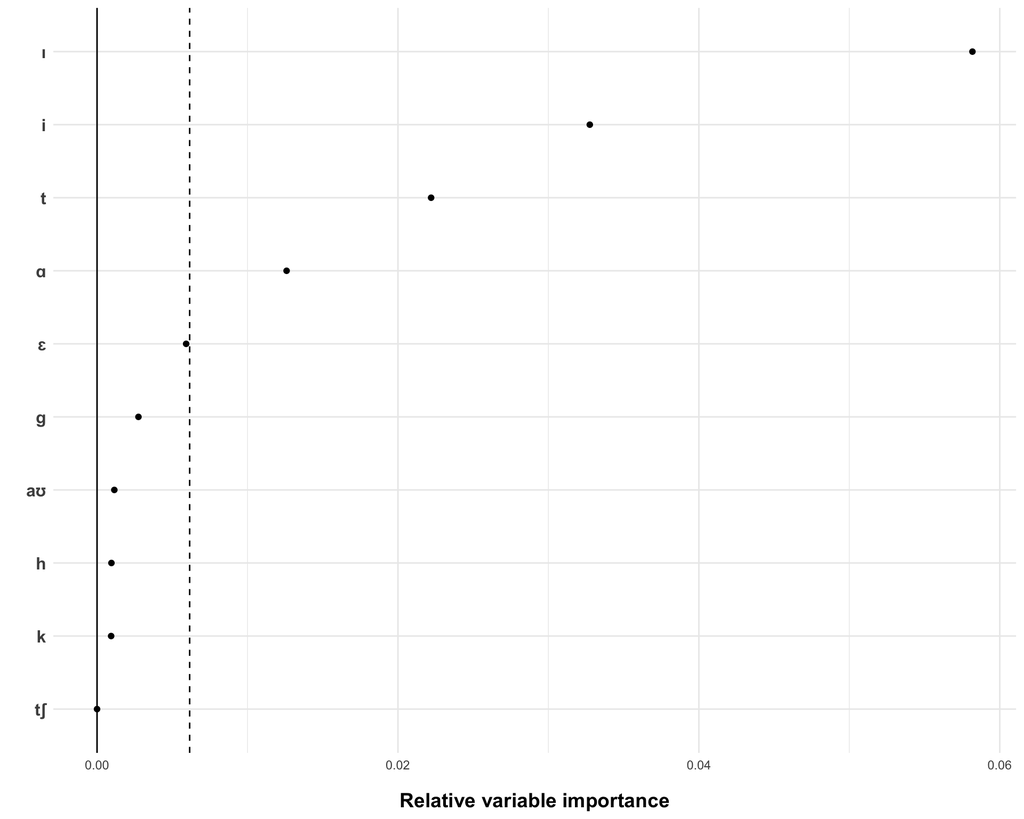

```r
all_importance_plot <- all_important %>%
  slice_head(n = 10) %>%
  ggplot(aes(x = reorder(IPA, Importance), y = Importance)) +
  geom_point() +
  ylab('Relative variable importance') +
  xlab('') +
  geom_hline(yintercept = abs(min(all_important$Importance)), linetype = 2) +
  geom_hline(yintercept = 0) +
  coord_flip() +
  theme_minimal() +
  theme(axis.title.x = element_text(face = 'bold',
                                    margin = margin(t = 15, b = 0,
                                                    r = 0, l = 0),
                                    size = 14),
        axis.text.y = element_text(face = 'bold',
                                   size = 12))

# Look:

all_importance_plot
```

```r
# Save:

ggsave(plot = all_importance_plot,
       filename = '../figures/variable_importances.png',
       width = 8, height = 5)
```

## Explore effects of most relevant predictors:

Create crosstabulations:

```r
IY_tab <- with(adj_red, table(SizeCat, IY_01))
IH_tab <- with(adj_red, table(SizeCat, IH_01))
T_tab <- with(adj_red, table(SizeCat, T_01))
AA_tab <- with(adj_red, table(SizeCat, AA_01))
```

Check the actual counts:

```r
IY_tab
```

```
##                 IY_01
## SizeCat           0  1
##   big/large/huge 33  1
##   small/tiny     13  5
```

```r
IH_tab
```

```
##                 IH_01
## SizeCat           0  1
##   big/large/huge 28  6
##   small/tiny     11  7
```

```r
T_tab
```

```
##                 T_01
## SizeCat           0  1
##   big/large/huge 21 13
##   small/tiny      7 11
```

```r
AA_tab
```

```
##                 AA_01
## SizeCat           0  1
##   big/large/huge 25  9
##   small/tiny     18  0
```

Check them with row-wise proportions:

```r
round(prop.table(IY_tab, 1), 2)
```

```
##                 IY_01
## SizeCat             0    1
##   big/large/huge 0.97 0.03
##   small/tiny     0.72 0.28
```

```r
round(prop.table(IH_tab, 1), 2)
```

```
##                 IH_01
## SizeCat             0    1
##   big/large/huge 0.82 0.18
##   small/tiny     0.61 0.39
```

```r
round(prop.table(T_tab, 1), 2)
```

```
##                 T_01
## SizeCat             0    1
##   big/large/huge 0.62 0.38
##   small/tiny     0.39 0.61
```

```r
round(prop.table(AA_tab, 1), 2)
```

```
##                 AA_01
## SizeCat             0    1
##   big/large/huge 0.74 0.26
##   small/tiny     1.00 0.00
```

Check effect sizes (Cramer’s V for contingency tables):

```r
cramersV(IY_tab)
```

```
## [1] 0.3065775
```

```r
cramersV(IH_tab)
```

```
## [1] 0.186704
```

```r
cramersV(T_tab)
```

```
## [1] 0.1777643
```

```r
cramersV(AA_tab)
```

```
## [1] 0.2794523
```

For df = 1, 0.10 = small, medium = 0.3, large = 0.5

## Vowel versus consonant forests

Fit random forests for vowels and consonants separately. First, we need to tune the hyperparameters again since we now have different predictor sets.

```r
# Select only columns that are relevant to the task at hand:

vowel_task <- bind_cols(adj_red[, str_c(vowels, '_01')],
                        select(adj_red, SizeCat))
consonant_task <- bind_cols(adj_red[, str_c(consonants, '_01')],
                            select(adj_red, SizeCat))

# Make all 01 columns into factors:

vowel_task <- vowel_task %>% mutate_if(is.double, as.factor)
consonant_task <- consonant_task %>% mutate_if(is.double, as.factor)

# Make into data frames:

vowel_task <- as.data.frame(vowel_task)
consonant_task <- as.data.frame(consonant_task)

# Make into task object:

vowel_task <- makeClassifTask(data = vowel_task, target = 'SizeCat')
consonant_task <- makeClassifTask(data = consonant_task, target = 'SizeCat')
```

Let’s tune these forests:

```r
set.seed(666) # a nice number
vowel_tunes <- tuneRanger(vowel_task, measure = list(multiclass.brier),
                        num.trees = 1000, num.threads = 4,
                        iters = 70, iters.warmup = 30)

consonant_tunes <- tuneRanger(consonant_task, measure = list(multiclass.brier),
                            num.trees = 1000, num.threads = 4,
                            iters = 70, iters.warmup = 30)
```

Check the recommended hyperparameters:

```r
vowel_tunes
```

```
## Recommended parameter settings:
##   mtry min.node.size sample.fraction
## 1    3             3       0.3281979
## Results:
##   multiclass.brier exec.time
## 1        0.4121398     0.151
```

```r
consonant_tunes
```

```
## Recommended parameter settings:
##   mtry min.node.size sample.fraction
## 1    8            11       0.2051173
## Results:
##   multiclass.brier exec.time
## 1         0.469354     0.153
```

Run the forests with the respective parameters:

```r
V_forest <- ranger(formula = str_c('SizeCat ~ ', V_formula_01),
                   importance = 'permutation', num.trees = 1000,
                   probability = FALSE,
                   seed = 666,
                   mtry = 3, min.node.size = 3,
                   sample.fraction = 0.3281979,
                   data = adj_red)

C_forest <- ranger(formula = str_c('SizeCat ~ ', C_formula_01),
                   importance = 'permutation', num.trees = 1000,
                   probability = FALSE,
                   mtry = 8,
                   min.node.size = 11,
                   sample.fraction = 0.2051173,
                   seed = 42,
                   data = adj_red)
```

Check:

```r
V_forest
```

```
## Ranger result
##
## Call:
##  ranger(formula = str_c("SizeCat ~ ", V_formula_01), importance = "permutation",      num.trees = 1000, probability = FALSE, seed = 666, mtry = 3,      min.node.size = 3, sample.fraction = 0.3281979, data = adj_red)
##
## Type:                             Classification
## Number of trees:                  1000
## Sample size:                      52
## Number of independent variables:  15
## Mtry:                             3
## Target node size:                 3
## Variable importance mode:         permutation
## Splitrule:                        gini
## OOB prediction error:             34.62 %
```

```r
C_forest
```

```
## Ranger result
##
## Call:
##  ranger(formula = str_c("SizeCat ~ ", C_formula_01), importance = "permutation",      num.trees = 1000, probability = FALSE, mtry = 8, min.node.size = 11,      sample.fraction = 0.2051173, seed = 42, data = adj_red)
##
## Type:                             Classification
## Number of trees:                  1000
## Sample size:                      52
## Number of independent variables:  24
## Mtry:                             8
## Target node size:                 11
## Variable importance mode:         permutation
## Splitrule:                        gini
## OOB prediction error:             34.62 %
```

Get predictions:

```r
V_preds <- predict(V_forest, data = adj_red)$predictions
C_preds <- predict(C_forest, data = adj_red)$predictions
```

Tables for classification accuracy:

```r
V_tab <- table(adj_red$SizeCat, V_preds)
C_tab <- table(adj_red$SizeCat, C_preds)
```

Check:

```r
V_tab
```

```
##                 V_preds
##                  big/large/huge small/tiny
##   big/large/huge             34          0
##   small/tiny                  9          9
```

```r
C_tab
```

```
##                 C_preds
##                  big/large/huge small/tiny
##   big/large/huge             34          0
##   small/tiny                 18          0
```

Check classification accuracy:

```r
sum(diag(V_tab)) / sum(V_tab)
```

```
## [1] 0.8269231
```

```r
sum(diag(C_tab)) / sum(C_tab)
```

```
## [1] 0.6538462
```

## Impact of etymological relatedness on random forest

How do the above compare to the dataset that has no etymological relatives (all independent data points)?

```r
red_forest_01 <- ranger(formula = str_c('SizeCat ~ ', all_formula_01),
                        importance = 'permutation',
                        probability = TRUE,
                        mtry = 29, min.node.size = 4, sample.fraction = 0.7873799,
                        seed = 666,
                        data = adj_red,
                        keep.inbag = TRUE)
red_forest_01
```

```
## Ranger result
##
## Call:
##  ranger(formula = str_c("SizeCat ~ ", all_formula_01), importance = "permutation",      probability = TRUE, mtry = 29, min.node.size = 4, sample.fraction = 0.7873799,      seed = 666, data = adj_red, keep.inbag = TRUE)
##
## Type:                             Probability estimation
## Number of trees:                  500
## Sample size:                      52
## Number of independent variables:  39
## Mtry:                             29
## Target node size:                 4
## Variable importance mode:         permutation
## Splitrule:                        gini
## OOB prediction error (Brier s.):  0.2186795
```

Check accuracy:

```r
red_preds_01 <- predict(red_forest_01, data = adj_red)$predictions
red_tab_01 <- table(adj_red$SizeCat,
                    ifelse(red_preds_01[, 1] >= 0.5,
                           'big/large/huge', 'small/tiny'))
sum(diag(red_tab_01)) / sum(red_tab_01)
```

```
## [1] 0.9423077
```

Check which words ranger is most certain about:

```r
adj_red$Probability <- red_preds_01[, 1]

# Big ordered by certainty:

big_probs <- filter(adj_red, SizeCat == 'big/large/huge') %>%
  select(Word, SizeCat, Probability) %>%
  arrange(desc(Probability))
big_probs %>% print(n = Inf)
```

```
## # A tibble: 34 x 3
##    Word         SizeCat        Probability
##    <chr>        <fct>                <dbl>
##  1 large        big/large/huge       0.957
##  2 mondo        big/large/huge       0.943
##  3 colossal     big/large/huge       0.929
##  4 hulking      big/large/huge       0.925
##  5 gargantuan   big/large/huge       0.910
##  6 goodly       big/large/huge       0.908
##  7 walloping    big/large/huge       0.908
##  8 whopping     big/large/huge       0.904
##  9 towering     big/large/huge       0.901
## 10 gross        big/large/huge       0.892
## 11 hefty        big/large/huge       0.887
## 12 leviathan    big/large/huge       0.882
```

[output cut: 22 more lines]

```r
# Small ordered by certainty:

small_probs <- filter(adj_red, SizeCat != 'big/large/huge') %>%
  select(Word, SizeCat, Probability) %>%
  arrange(Probability)
small_probs %>% print(n = Inf)
```

```
## # A tibble: 18 x 3
##    Word          SizeCat    Probability
##    <chr>         <fct>            <dbl>
##  1 petite        small/tiny       0.108
##  2 pee-wee       small/tiny       0.118
##  3 teensy        small/tiny       0.126
##  4 little        small/tiny       0.158
##  5 lilliputian   small/tiny       0.160
##  6 mini          small/tiny       0.166
##  7 meager        small/tiny       0.167
##  8 infinitesimal small/tiny       0.188
##  9 diminutive    small/tiny       0.202
## 10 midget        small/tiny       0.231
## 11 bitsy         small/tiny       0.266
## 12 microscopic   small/tiny       0.455
## 13 baby          small/tiny       0.463
## 14 slight        small/tiny       0.494
## 15 puny          small/tiny       0.497
## 16 bantam        small/tiny       0.501
## 17 small         small/tiny       0.503
## 18 runty         small/tiny       0.543
```

Write this to a table:

```r
word_table <- bind_rows(small_probs, big_probs) %>%
  mutate(Probability = round(Probability, 2))
write_csv(word_table, '../data/random_forestclassifications.csv')
```

## Glasgow norms:

Extract size and the Glasgow concreteness ratings:

```r
glasgow <- select(glasgow,
                  Word, Concreteness, Size)
nrow(glasgow) # Check
```

```
## [1] 5553
```

Clean Glasgow norms — get rid of the sense information so that we can merge word senses:

```r
glasgow <- mutate(glasgow,
                  Word = str_replace(Word, ' \\(.+?\\)', ''))
```

Show duplicate examples:

```r
filter(glasgow, duplicated(Word))
```

```
## # A tibble: 870 x 3
##    Word    Concreteness  Size
##    <chr>          <dbl> <dbl>
##  1 address         5.58  3.47
##  2 address         4.11  4.17
##  3 aim             3.29  4.5
##  4 aim             4.68  3.69
##  5 apple           6.76  2.31
##  6 arm             6.69  3.39
##  7 arm             5.76  4.94
##  8 arms            6.74  3.6
##  9 arms            6.24  5.44
## 10 ass             6.81  3.49
## # … with 860 more rows
```

Duplicates are different senses of the same word. For this we will merge:

```r
glasgow <- glasgow %>% group_by(Word) %>%
  summarize(Size = mean(Size),
            Concreteness = mean(Concreteness))
nrow(glasgow) # Check
```

```
## [1] 4683
```

Merge with morpheme data:

```r
glasgow <- left_join(glasgow, select(ELP, Word, NMorph))
```

For how many do we have morpheme data?

```r
sum(!is.na(glasgow$NMorph))
```

```
## [1] 4636
```

```r
sum(!is.na(glasgow$NMorph)) / nrow(glasgow)
```

```
## [1] 0.9899637
```

For most of them.

Let’s get only the monomorphemic words:

```r
glasgow <- filter(glasgow, NMorph == 1)
nrow(glasgow)
```

```
## [1] 2796
```

Merge with pronuciations:

```r
glasgow <- left_join(glasgow, filter(CMU, !duplicated(Word)))
```

For how many do we not have pronunciations?

```r
# Missing pronunciations for these:

sum(is.na(glasgow$AA))
```

```
## [1] 27
```

```r
sum(is.na(glasgow$AA)) / nrow(glasgow) # only 1%
```

```
## [1] 0.009656652
```

```r
nrow(glasgow) - sum(is.na(glasgow$AA))
```

```
## [1] 2769
```

Get rid of those for which we have no pronunciations:

```r
glasgow <- filter(glasgow, !is.na(AA))
nrow(glasgow)
```

```
## [1] 2769
```

Get word length as phoneme count:

```r
glasgow$NPhon <- rowSums(select(glasgow, AA:ZH))
```

Make phoneme columns into a present/absent variable:

```r
glasgow[, colnames(select(glasgow, AA:ZH))] <- apply(select(glasgow, AA:ZH), 2,
                                                     FUN = function(x) ifelse(x >= 1, 1, 0))
```

Merge with SUBTL POS tags:

```r
glasgow <- left_join(glasgow, SUBTL)
```

Check POS tags (this is the DOMINANT POS tag, that is, whatever this word was used most frequently as in the corpus):

```r
table(glasgow$POS)
```

```
##
##    Adjective       Adverb      Article  Conjunction   Determiner Interjection
##          330           27            1            1            9            3
##         Name         Noun       Number  Preposition      Pronoun         Verb
##           47         1865            4            9            1          472
```

```r
nrow(glasgow)
```

```
## [1] 2769
```

```r
glasgow <- filter(glasgow,
                  POS %in% c('Adjective', 'Verb', 'Noun'))

# Check:

table(glasgow$POS)
```

```
##
## Adjective      Noun      Verb
##       330      1865       472
```

```r
nrow(glasgow)
```

```
## [1] 2667
```

For comparison, we will create a forest with a median split dataset:

```r
glasgow <- mutate(glasgow,
                  SizeCat = ifelse(Size > median(Size), 'large', 'small'),
                  SizeCat = factor(SizeCat))
```

Get adj/noun/verb subsets:

```r
glasgow_adj <- filter(glasgow, POS == 'Adjective')
glasgow_verb <- filter(glasgow, POS == 'Verb')
glasgow_noun <- filter(glasgow, POS == 'Noun')
```

Tune hyperparameters to this data:

```r
# Select only columns that are relevant to the task at hand:

glasgow_task <- bind_cols(select(glasgow, SizeCat),
                      select(glasgow, AA:ZH))
glasgow_adj_task <- bind_cols(select(glasgow_adj, SizeCat),
                          select(glasgow_adj, AA:ZH))
glasgow_verb_task <- bind_cols(select(glasgow_verb, SizeCat),
                          select(glasgow_verb, AA:ZH))
glasgow_noun_task <- bind_cols(select(glasgow_noun, SizeCat),
                          select(glasgow_noun, AA:ZH))

# Make all 01 columns into factors:

glasgow_task <- glasgow_task %>% mutate_if(is.double, as.factor)
glasgow_adj_task <- glasgow_adj_task %>% mutate_if(is.double, as.factor)
glasgow_verb_task <- glasgow_verb_task %>% mutate_if(is.double, as.factor)
glasgow_noun_task <- glasgow_noun_task %>% mutate_if(is.double, as.factor)

# Make into data frames:

glasgow_task <- as.data.frame(glasgow_task)
glasgow_adj_task <- as.data.frame(glasgow_adj_task)
glasgow_verb_task <- as.data.frame(glasgow_verb_task)
glasgow_noun_task <- as.data.frame(glasgow_noun_task)

# Make into task object:

glasgow_task <- makeClassifTask(data = glasgow_task, target = 'SizeCat')
glasgow_adj_task <- makeClassifTask(data = glasgow_adj_task, target = 'SizeCat')
glasgow_verb_task <- makeClassifTask(data = glasgow_verb_task, target = 'SizeCat')
glasgow_noun_task <- makeClassifTask(data = glasgow_noun_task, target = 'SizeCat')
```

Let’s tune the tree:

```r
set.seed(666) # a nice number
glasgow_tunes <- tuneRanger(glasgow_task, measure = list(multiclass.brier),
                            num.trees = 1000, num.threads = 4,
                            iters = 70, iters.warmup = 30)

glasgow_adj_tunes <- tuneRanger(glasgow_adj_task, measure = list(multiclass.brier),
                                num.trees = 1000, num.threads = 4,
                                iters = 70, iters.warmup = 30)

glasgow_verb_tunes <- tuneRanger(glasgow_verb_task, measure = list(multiclass.brier),
                                 num.trees = 1000, num.threads = 4,
                                 iters = 70, iters.warmup = 30)

glasgow_noun_tunes <- tuneRanger(glasgow_noun_task, measure = list(multiclass.brier),
                                 num.trees = 1000, num.threads = 4,
                                 iters = 70, iters.warmup = 30)
```

Check recommended hyperparameter settings:

```r
glasgow_tunes
```

```
## Recommended parameter settings:
##   mtry min.node.size sample.fraction
## 1    4             8        0.251633
## Results:
##   multiclass.brier exec.time
## 1         0.483925    0.5166
```

```r
glasgow_adj_tunes
```

```
## Recommended parameter settings:
##   mtry min.node.size sample.fraction
## 1    4             4       0.3790906
## Results:
##   multiclass.brier exec.time
## 1        0.4819157    0.1904
```

```r
glasgow_verb_tunes
```

```
## Recommended parameter settings:
##   mtry min.node.size sample.fraction
## 1    5            84       0.8328327
## Results:
##   multiclass.brier exec.time
## 1        0.4831161    0.1726
```

```r
glasgow_noun_tunes
```

```
## Recommended parameter settings:
##   mtry min.node.size sample.fraction
## 1   11            51       0.2235099
## Results:
##   multiclass.brier exec.time
## 1        0.4855879    0.3456
```

Create the formula:

```r
all_formula <- str_c(c(consonants, vowels), collapse = ' + ')
```

Fit random forests:

```r
glasgow_forest <- ranger(formula = str_c('SizeCat ~ ', all_formula),
                         importance = 'permutation', num.trees = 1000,
                         probability = FALSE,
                         mtry = 4,
                         min.node.size = 8,
                         sample.fraction = 0.251633,
                         seed = 42,
                         data = glasgow)

glasgow_adj_forest <- ranger(formula = str_c('SizeCat ~ ', all_formula),
                             importance = 'permutation', num.trees = 1000,
                             probability = FALSE,
                             mtry = 4,
                             min.node.size = 4,
                             sample.fraction = 0.3790906,
                             seed = 42,
                             data = glasgow_adj)

glasgow_verb_forest <- ranger(formula = str_c('SizeCat ~ ', all_formula),
                              importance = 'permutation', num.trees = 1000,
                              probability = FALSE,
                              mtry = 5,
                              min.node.size = 84,
                              sample.fraction = 0.8328327,
                              seed = 42,
                              data = glasgow_verb)

glasgow_noun_forest <- ranger(formula = str_c('SizeCat ~ ', all_formula),
                              importance = 'permutation', num.trees = 1000,
                              probability = FALSE,
                              mtry = 11,
                              min.node.size = 51,
                              sample.fraction = 0.2235099,
                              seed = 42,
                              data = glasgow_noun)
```

Check the forest performance:

```r
glasgow_forest
```

```
## Ranger result
##
## Call:
##  ranger(formula = str_c("SizeCat ~ ", all_formula), importance = "permutation",      num.trees = 1000, probability = FALSE, mtry = 4, min.node.size = 8,      sample.fraction = 0.251633, seed = 42, data = glasgow)
##
## Type:                             Classification
## Number of trees:                  1000
## Sample size:                      2667
## Number of independent variables:  39
## Mtry:                             4
## Target node size:                 8
## Variable importance mode:         permutation
## Splitrule:                        gini
## OOB prediction error:             41.62 %
```

```r
glasgow_noun_forest
```

```
## Ranger result
##
## Call:
##  ranger(formula = str_c("SizeCat ~ ", all_formula), importance = "permutation",      num.trees = 1000, probability = FALSE, mtry = 11, min.node.size = 51,      sample.fraction = 0.2235099, seed = 42, data = glasgow_noun)
##
## Type:                             Classification
## Number of trees:                  1000
## Sample size:                      1865
## Number of independent variables:  39
## Mtry:                             11
## Target node size:                 51
## Variable importance mode:         permutation
## Splitrule:                        gini
## OOB prediction error:             43.00 %
```

```r
glasgow_verb_forest
```

```
## Ranger result
##
## Call:
##  ranger(formula = str_c("SizeCat ~ ", all_formula), importance = "permutation",      num.trees = 1000, probability = FALSE, mtry = 5, min.node.size = 84,      sample.fraction = 0.8328327, seed = 42, data = glasgow_verb)
##
## Type:                             Classification
## Number of trees:                  1000
## Sample size:                      472
## Number of independent variables:  39
## Mtry:                             5
## Target node size:                 84
## Variable importance mode:         permutation
## Splitrule:                        gini
## OOB prediction error:             46.61 %
```

```r
glasgow_adj_forest
```

```
## Ranger result
##
## Call:
##  ranger(formula = str_c("SizeCat ~ ", all_formula), importance = "permutation",      num.trees = 1000, probability = FALSE, mtry = 4, min.node.size = 4,      sample.fraction = 0.3790906, seed = 42, data = glasgow_adj)
##
## Type:                             Classification
## Number of trees:                  1000
## Sample size:                      330
## Number of independent variables:  39
## Mtry:                             4
## Target node size:                 4
## Variable importance mode:         permutation
## Splitrule:                        gini
## OOB prediction error:             44.55 %
```

Get the predictions:

```r
glasgow_preds <- predict(glasgow_forest, data = glasgow)$predictions
glasgow_verb_preds <- predict(glasgow_verb_forest, data = glasgow_verb)$predictions
glasgow_noun_preds <- predict(glasgow_noun_forest, data = glasgow_noun)$predictions
glasgow_adj_preds <- predict(glasgow_adj_forest, data = glasgow_adj)$predictions
```

Get contigency tables of real versus predicted:

```r
glas_tab <- table(glasgow$SizeCat, glasgow_preds)
verb_tab <- table(glasgow_verb$SizeCat, glasgow_verb_preds)
noun_tab <- table(glasgow_noun$SizeCat, glasgow_noun_preds)
adj_tab <- table(glasgow_adj$SizeCat, glasgow_adj_preds)
```

Check the accuracies of theese:

```r
sum(diag(glas_tab)) / sum(glas_tab)
```

```
## [1] 0.720285
```

```r
sum(diag(verb_tab)) / sum(verb_tab)
```

```
## [1] 0.6949153
```

```r
sum(diag(noun_tab)) / sum(noun_tab)
```

```
## [1] 0.6402145
```

```r
sum(diag(adj_tab)) / sum(adj_tab)
```

```
## [1] 0.8636364
```

Get the importances:

```r
glas_important <- sort(glasgow_forest$variable.importance, decreasing = TRUE)
verb_important <- sort(glasgow_verb_forest$variable.importance, decreasing = TRUE)
noun_important <- sort(glasgow_noun_forest$variable.importance, decreasing = TRUE)
adj_important <- sort(glasgow_adj_forest$variable.importance, decreasing = TRUE)
```

Put these into tibbles:

```r
glas_important <- tibble(Phoneme = names(glas_important),
                         Importance = glas_important) %>%
  right_join(select(phones, Phoneme, IPA))
verb_important <- tibble(Phoneme = names(verb_important),
                         Importance = verb_important) %>%
  right_join(select(phones, Phoneme, IPA))
noun_important <- tibble(Phoneme = names(noun_important),
                         Importance = noun_important) %>%
  right_join(select(phones, Phoneme, IPA))
adj_important <- tibble(Phoneme = names(adj_important),
                         Importance = adj_important) %>%
  right_join(select(phones, Phoneme, IPA))
```

Check them:

```r
glas_important
```

```
## # A tibble: 39 x 3
##    Phoneme Importance IPA
##    <chr>        <dbl> <chr>
##  1 R          0.00434 r
##  2 AO         0.00239 ɔ
##  3 V          0.00208 v
##  4 N          0.00205 n
##  5 AH         0.00188 ʌ
##  6 K          0.00175 k
##  7 P          0.00151 p
##  8 B          0.00145 b
##  9 ER         0.00140 ɝ
## 10 JH         0.00133 dʒ
## # … with 29 more rows
```

```r
verb_important
```

```
## # A tibble: 39 x 3
##    Phoneme Importance IPA
##    <chr>        <dbl> <chr>
##  1 EY        0.00852  eɪ
##  2 V         0.00783  v
##  3 S         0.00224  s
##  4 N         0.00185  n
##  5 AY        0.00181  aɪ
##  6 R         0.00168  r
##  7 L         0.00166  l
##  8 Z         0.00144  z
##  9 SH        0.000900 ʃ
## 10 F         0.000803 f
## # … with 29 more rows
```

```r
noun_important
```

```
## # A tibble: 39 x 3
##    Phoneme Importance IPA
##    <chr>        <dbl> <chr>
##  1 AO        0.00432  ɔ
##  2 JH        0.00387  dʒ
##  3 R         0.00364  r
##  4 P         0.00311  p
##  5 K         0.00180  k
##  6 AH        0.00158  ʌ
##  7 N         0.00156  n
##  8 ER        0.00148  ɝ
##  9 M         0.000856 m
## 10 B         0.000840 b
## # … with 29 more rows
```

```r
adj_important
```

```
## # A tibble: 39 x 3
##    Phoneme Importance IPA
##    <chr>        <dbl> <chr>
##  1 AH         0.00490 ʌ
##  2 HH         0.00487 h
##  3 L          0.00481 l
##  4 R          0.00418 r
##  5 IY         0.00293 ɪ
##  6 S          0.00192 s
##  7 UH         0.00187 ʊ
##  8 V          0.00182 v
##  9 K          0.00110 k
## 10 N          0.00103 n
## # … with 29 more rows
```

Make a plot of the most predictive segments for Glasgow norms:

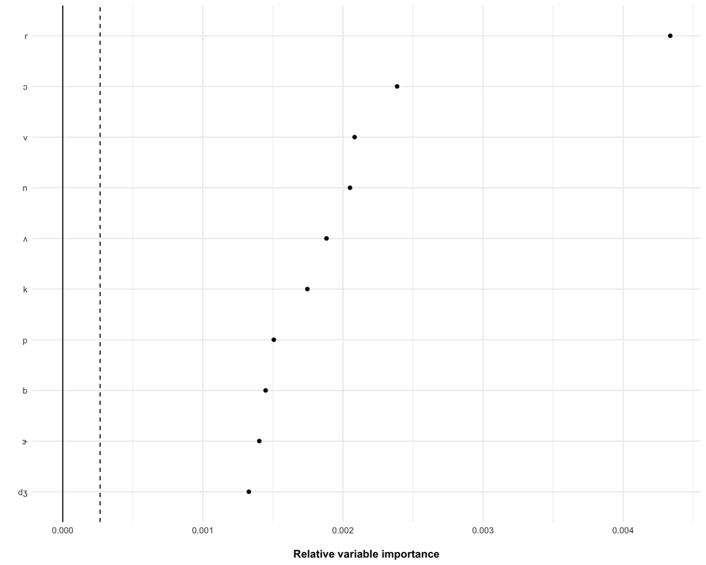

```r
glas_important_plot <- glas_important %>%
  slice_head(n = 10) %>%
  ggplot(aes(x = reorder(IPA, Importance), y = Importance)) +
  geom_point() +
  ylab('Relative variable importance') +
  xlab('') +
  geom_hline(yintercept = abs(min(glas_important$Importance)), linetype = 2) +
  geom_hline(yintercept = 0) +
  coord_flip() +
  theme_minimal() +
  theme(axis.title.x = element_text(face = 'bold',
                                    margin = margin(t = 15, b = 0,
                                                    r = 0, l = 0)))

# Look:

glas_important_plot
```

Same for verbs:

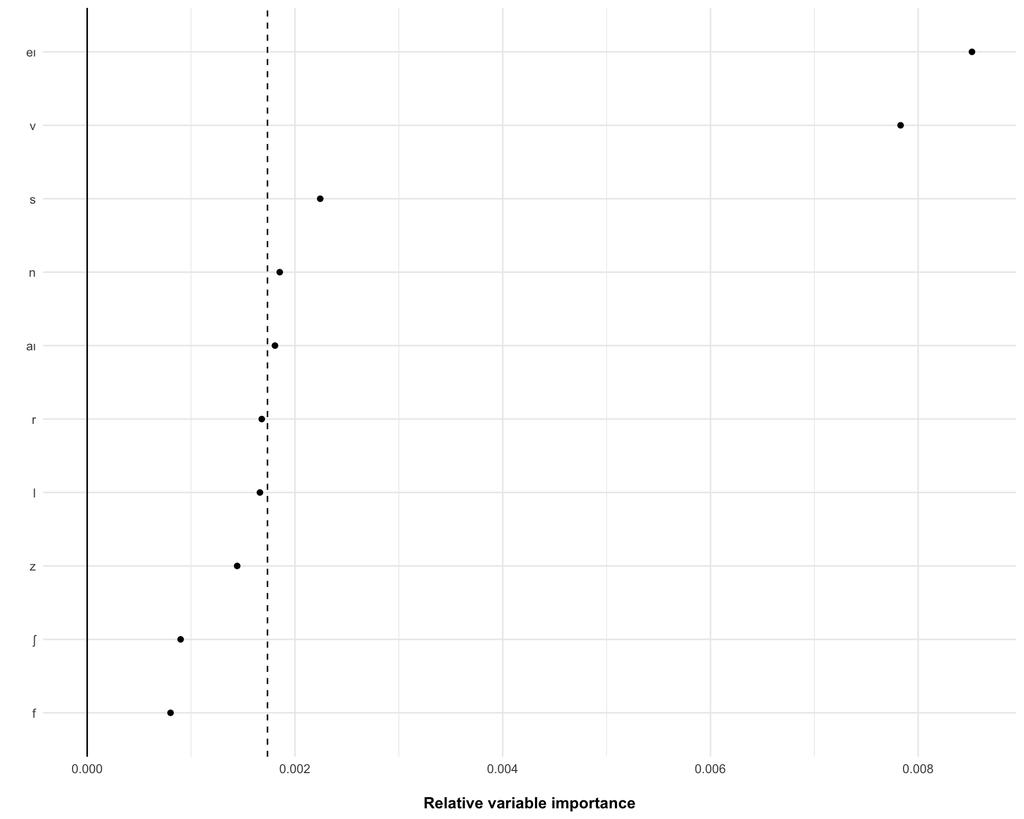

```r
verb_important_plot <- verb_important %>%
  slice_head(n = 10) %>%
  ggplot(aes(x = reorder(IPA, Importance), y = Importance)) +
  geom_point() +
  ylab('Relative variable importance') +
  xlab('') +
  geom_hline(yintercept = abs(min(verb_important$Importance)), linetype = 2) +
  geom_hline(yintercept = 0) +
  coord_flip() +
  theme_minimal() +
  theme(axis.title.x = element_text(face = 'bold',
                                    margin = margin(t = 15, b = 0,
                                                    r = 0, l = 0)))

# Look:

verb_important_plot
```

Same for nouns:

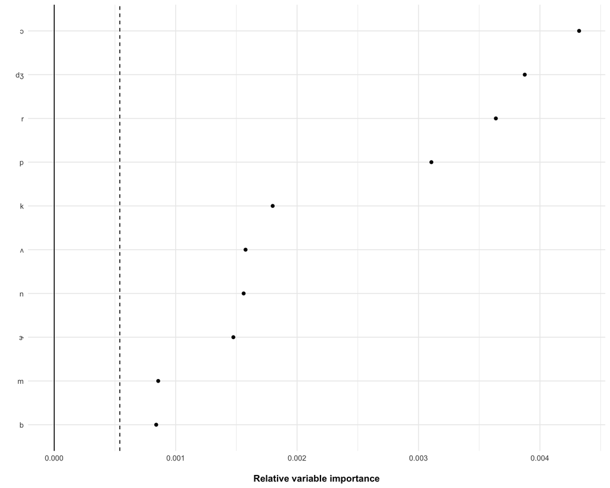

```r
noun_important_plot <- noun_important %>%
  slice_head(n = 10) %>%
  ggplot(aes(x = reorder(IPA, Importance), y = Importance)) +
  geom_point() +
  ylab('Relative variable importance') +
  xlab('') +
  geom_hline(yintercept = abs(min(noun_important$Importance)), linetype = 2) +
  geom_hline(yintercept = 0) +
  coord_flip() +
  theme_minimal() +
  theme(axis.title.x = element_text(face = 'bold',
                                    margin = margin(t = 15, b = 0,
                                                    r = 0, l = 0)))

# Look:

noun_important_plot
```

Same for adjectives:

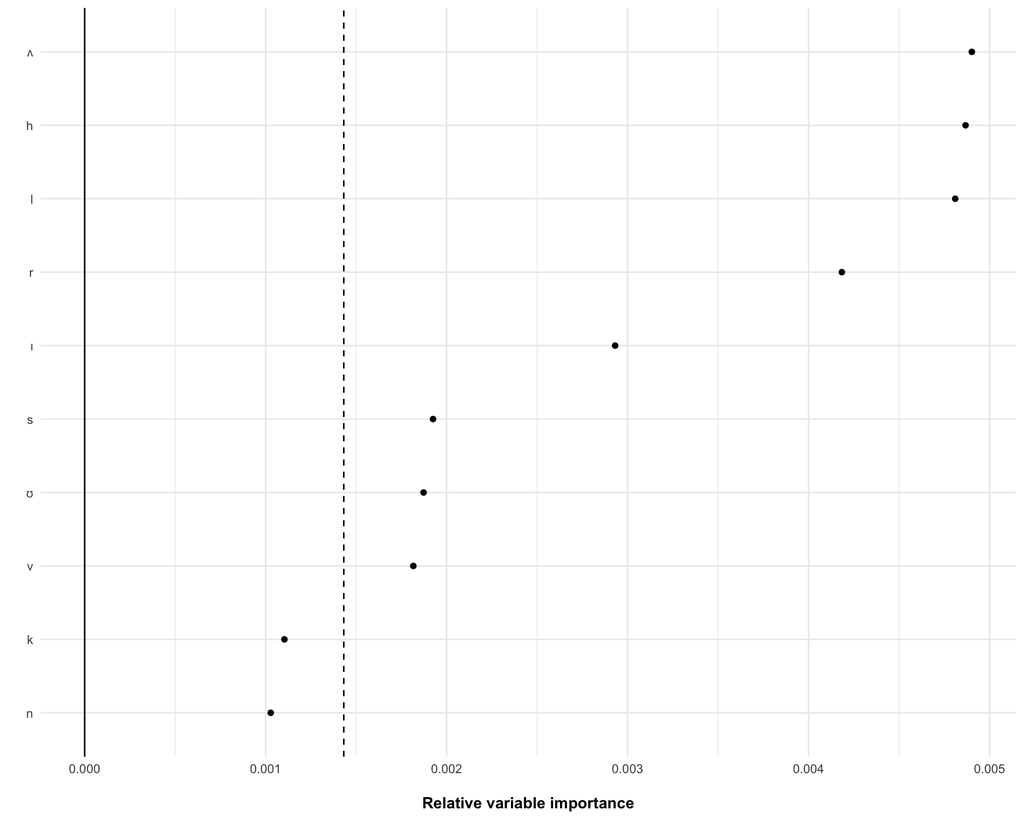

```r
adj_important_plot <- adj_important %>%
  slice_head(n = 10) %>%
  ggplot(aes(x = reorder(IPA, Importance), y = Importance)) +
  geom_point() +
  ylab('Relative variable importance') +
  xlab('') +
  geom_hline(yintercept = abs(min(adj_important$Importance)), linetype = 2) +
  geom_hline(yintercept = 0) +
  coord_flip() +
  theme_minimal() +
  theme(axis.title.x = element_text(face = 'bold',
                                    margin = margin(t = 15, b = 0,
                                                    r = 0, l = 0)))

# Look:

adj_important_plot
```

Check individual patterns, all data:

```r
tab_1 <- with(glasgow, table(SizeCat, R)) # 1st phoneme, r
tab_2 <- with(glasgow, table(SizeCat, AO)) # 2nd phoneme, O
tab_3 <- with(glasgow, table(SizeCat, V)) # 2nd phoneme, O

cramersV(tab_1)
```

```
## [1] 0.0848719
```

```r
cramersV(tab_2)
```

```
## [1] 0.06392828
```

```r
cramersV(tab_3)
```

```
## [1] 0.06247428
```

Check individual patterns, verb:

```r
tab_1 <- with(glasgow_verb, table(SizeCat, EY)) # 1st phoneme, ei
tab_2 <- with(glasgow_verb, table(SizeCat, V)) # 2nd phoneme, v
tab_3 <- with(glasgow_verb, table(SizeCat, S)) # 2nd phoneme, s

cramersV(tab_1)
```

```
## [1] 0.1204943
```

```r
cramersV(tab_2)
```

```
## [1] 0.1304495
```

```r
cramersV(tab_3)
```

```
## [1] 0.06694246
```

Check individual patterns, noun:

```r
tab_1 <- with(glasgow_noun, table(SizeCat, AO)) # 1st phoneme, ei
tab_2 <- with(glasgow_noun, table(SizeCat, JH)) # 2nd phoneme, v
tab_3 <- with(glasgow_noun, table(SizeCat, R)) # 2nd phoneme, s

cramersV(tab_1)
```

```
## [1] 0.08204612
```

```r
cramersV(tab_2)
```

```
## [1] 0.07107286
```

```r
cramersV(tab_3)
```

```
## [1] 0.08134744
```

Check individual patterns, adjectives:

```r
tab_1 <- with(glasgow_adj, table(SizeCat, AH)) # 1st phoneme, V
tab_2 <- with(glasgow_adj, table(SizeCat, HH)) # 2nd phoneme, h
tab_3 <- with(glasgow_adj, table(SizeCat, L)) # 2nd phoneme, l

prop.table(tab_1, 1)
```

```
##        AH
## SizeCat         0         1
##   large 0.6179775 0.3820225
##   small 0.7434211 0.2565789
```

```r
prop.table(tab_2, 1)
```

```
##        HH
## SizeCat           0           1
##   large 0.938202247 0.061797753
##   small 0.993421053 0.006578947
```

```r
prop.table(tab_3, 1)
```

```
##        L
## SizeCat         0         1
##   large 0.7191011 0.2808989
##   small 0.6184211 0.3815789
```

```r
cramersV(tab_1)
```

```
## [1] 0.1270843
```

```r
cramersV(tab_2)
```

```
## [1] 0.1307944
```

```r
cramersV(tab_3)
```

```
## [1] 0.1004732
```

Check Cohen’s d:

```r
cohen.d(Size ~ R, data = glasgow)
```

```
##
## Cohen's d
##
## d estimate: -0.1912231 (negligible)
## 95 percent confidence interval:
##      lower      upper
## -0.2759351 -0.1065110
```

```r
cohen.d(Size ~ AO, data = glasgow)
```

```
##
## Cohen's d
##
## d estimate: -0.2159639 (small)
## 95 percent confidence interval:
##       lower       upper
## -0.36703702 -0.06489082
```

```r
cohen.d(Size ~ V, data = glasgow)
```

```
##
## Cohen's d
##
## d estimate: -0.3131856 (small)
## 95 percent confidence interval:
##      lower      upper
## -0.4766803 -0.1496910
```

## 10th percentile analysis

Get the 10th percentile largest and smallest words from the Glasgow norm dataset to give it a better chance:

```r
glasgow$Size_10 <- as.character(rep(NA, nrow(glasgow)))
glasgow$Size_20 <- as.character(rep(NA, nrow(glasgow)))
glasgow <- mutate(glasgow,
                  Size_10 = ifelse(Size > quantile(Size, 0.9), 'large', Size_10),
                  Size_10 = ifelse(Size < quantile(Size, 0.10), 'small', Size_10),
                  Size_20 = ifelse(Size > quantile(Size, 0.8), 'large', Size_20),
                  Size_20 = ifelse(Size < quantile(Size, 0.20), 'small', Size_20))
```

Create the task objects for hyperparameter tuning:

```r
glasgow_10 <- bind_cols(select(glasgow, Size_10),
                        select(glasgow, AA:ZH))
glasgow_20 <- bind_cols(select(glasgow, Size_20),
                        select(glasgow, AA:ZH))

# Get rid of the remaining ones (NAs, those that are not within those extreme percentiles):

glasgow_10 <- filter(glasgow_10, !is.na(Size_10))
glasgow_20 <- filter(glasgow_20, !is.na(Size_20))

# Conver columns:

glasgow_10 <- glasgow_10 %>% mutate_if(is.double, as.factor)
glasgow_20 <- glasgow_20 %>% mutate_if(is.double, as.factor)

# Make into data frame objects:

glasgow_10 <- as.data.frame(glasgow_10)
glasgow_20 <- as.data.frame(glasgow_20)

# Make category into factor:

glasgow_10 <- mutate(glasgow_10,
                     Size_10 = as.factor(Size_10))
glasgow_20 <- mutate(glasgow_20,
                     Size_20 = as.factor(Size_20))

# Make into task objects:

glasgow_10_task <- makeClassifTask(data = glasgow_10, target = 'Size_10')
glasgow_20_task <- makeClassifTask(data = glasgow_20, target = 'Size_20')
```

Tune these forests:

```r
set.seed(666) # a nice number
glasgow_10_tunes <- tuneRanger(glasgow_10_task, measure = list(multiclass.brier),
                               num.trees = 1000, num.threads = 4,
                               iters = 70, iters.warmup = 30)
glasgow_20_tunes <- tuneRanger(glasgow_20_task, measure = list(multiclass.brier),
                               num.trees = 1000, num.threads = 4,
                               iters = 70, iters.warmup = 30)
```

Check recommended hyperparameters:

```r
glasgow_10_tunes
```

```
## Recommended parameter settings:
##   mtry min.node.size sample.fraction
## 1    4             2       0.4216094
## Results:
##   multiclass.brier exec.time
## 1        0.4836489    0.2378
```

```r
glasgow_20_tunes
```

```
## Recommended parameter settings:
##   mtry min.node.size sample.fraction
## 1   32            11       0.2047053
## Results:
##   multiclass.brier exec.time
## 1        0.4616213    0.3406
```

Run the forest with those specs:

```r
glas_10_ranger <- ranger(formula = str_c('Size_10 ~ ', all_formula),
                         probability = FALSE,
                         data = glasgow_10,
                         mtry = 4, min.node.size = 2, sample.fraction = 0.4216094,
                         num.trees = 1000,
                         seed = 666,
                         importance = 'permutation')
glas_20_ranger <- ranger(formula = str_c('Size_20 ~ ', all_formula),
                         probability = FALSE,
                         data = glasgow_20,
                         mtry = 32, min.node.size = 11, sample.fraction = 0.2047053,
                         num.trees = 1000,
                         seed = 666,
                         importance = 'permutation')
```

Check the forests:

```r
glas_10_ranger
```

```
## Ranger result
##
## Call:
##  ranger(formula = str_c("Size_10 ~ ", all_formula), probability = FALSE,      data = glasgow_10, mtry = 4, min.node.size = 2, sample.fraction = 0.4216094,      num.trees = 1000, seed = 666, importance = "permutation")
##
## Type:                             Classification
## Number of trees:                  1000
## Sample size:                      533
## Number of independent variables:  39
## Mtry:                             4
## Target node size:                 2
## Variable importance mode:         permutation
## Splitrule:                        gini
## OOB prediction error:             40.90 %
```

```r
glas_20_ranger
```

```
## Ranger result
##
## Call:
##  ranger(formula = str_c("Size_20 ~ ", all_formula), probability = FALSE,      data = glasgow_20, mtry = 32, min.node.size = 11, sample.fraction = 0.2047053,      num.trees = 1000, seed = 666, importance = "permutation")
##
## Type:                             Classification
## Number of trees:                  1000
## Sample size:                      1065
## Number of independent variables:  39
## Mtry:                             32
## Target node size:                 11
## Variable importance mode:         permutation
## Splitrule:                        gini
## OOB prediction error:             37.93 %
```

Get the prediction accuracy. Get predictions:

```r
glas_10_preds <- predict(glas_10_ranger, data = glasgow_10)$predictions
glas_20_preds <- predict(glas_20_ranger, data = glasgow_20)$predictions
```

Tables for classification accuracy:

```r
glas_10_tab <- table(glasgow_10$Size_10, glas_10_preds)
glas_20_tab <- table(glasgow_20$Size_20, glas_20_preds)
```

Check:

```r
glas_10_tab
```

```
##        glas_10_preds
##         large small
##   large   207    60
##   small    17   249
```

```r
glas_20_tab
```

```
##        glas_20_preds
##         large small
##   large   419   112
##   small   138   396
```

Check classification accuracy:

```r
sum(diag(glas_10_tab)) / sum(glas_10_tab)
```

```
## [1] 0.8555347
```

```r
sum(diag(glas_20_tab)) / sum(glas_20_tab)
```

```
## [1] 0.7652582
```

Most predictive phonemes:

```r
sort(glas_10_ranger$variable.importance)
```

```
##            NG            AH            CH            OW            EH
## -6.247033e-04 -5.684038e-04 -5.138644e-04 -4.308355e-04 -4.208909e-04
##            UW             N             G            OY            DH
## -3.996173e-04 -3.892565e-04 -3.824834e-04 -2.186907e-04  0.000000e+00
##             Y             F             T            AW            ZH
##  2.956074e-05  1.814237e-04  2.213103e-04  2.351203e-04  2.826827e-04
##             W            UH            IH            AO            EY
##  4.878356e-04  5.018757e-04  5.812215e-04  5.841114e-04  6.764848e-04
##            TH            AE            SH             L             M
##  8.282990e-04  9.069915e-04  1.015474e-03  1.209570e-03  1.222486e-03
##            IY            JH            AY            ER             B
##  1.380177e-03  1.390728e-03  1.416418e-03  1.441651e-03  1.720333e-03
##             D            HH            AA             Z             K
##  1.891314e-03  1.904015e-03  2.042233e-03  2.047653e-03  2.180624e-03
##             S             R             P             V
##  2.359091e-03  2.897595e-03  4.208330e-03  4.898381e-03
```

```r
sort(glas_20_ranger$variable.importance)
```

```
##            UW             G            OW            CH            AW
## -6.584548e-04 -5.819584e-04 -4.611425e-04 -4.515751e-04 -2.605555e-04
##             W            EY            OY            DH             T
## -2.112554e-04 -2.102966e-04 -1.428382e-04 -1.615346e-05  2.142035e-05
##            ZH            NG            UH             F            IH
##  2.415070e-05  3.444979e-05  6.677834e-05  6.744291e-05  9.094347e-05
##             Y            AY             S            TH             K
##  2.374082e-04  5.024171e-04  6.635496e-04  7.248276e-04  8.264765e-04
##             N            AH            HH             L            SH
##  1.254474e-03  1.337705e-03  1.394433e-03  1.518831e-03  1.539717e-03
##            AA            AE             M            ER            IY
##  1.561445e-03  1.730266e-03  1.748607e-03  1.852356e-03  1.919463e-03
##            EH             B             P             D            JH
##  2.044972e-03  2.161648e-03  2.253969e-03  2.445675e-03  2.638676e-03
##            AO             Z             V             R
##  2.830478e-03  3.022924e-03  5.279043e-03  7.419682e-03
```